# 3.0 Methodology

# 3.1 Data Collection

## Import Libraries

```python
import os

import pandas as pd
import numpy as np
import matplotlib.pyplot as plt
```

## Import dataset

```python
filename = 'new.csv'
housing_raw = pd.read_csv(filename, encoding= 'unicode_escape')


IMAGES_PATH = 'Images'
```

# 3.2 Explorary Data Analysis (EDA)

## Examine data type

```python
print(housing_raw.dtypes)
```

```
url                     object
id                      object
Lng                    float64
Lat                    float64
Cid                      int64
tradeTime               object
DOM                    float64
followers                int64
totalPrice             float64
price                    int64
square                 float64
livingRoom              object
drawingRoom             object
kitchen                  int64
bathRoom                object
floor                   object
buildingType           float64
constructionTime        object
renovationCondition      int64
buildingStructure        int64
ladderRatio            float64
elevator               float64
fiveYearsProperty      float64
subway                 float64
district                 int64
communityAverage       float64
dtype: object
```

## Examine the basic summary of data

```python
housing_raw.describe()
```

|  | Lng | Lat | Cid | DOM | followers | totalPrice | price | square | kitchen | buildingType | renovationCondition | buildingStructure | ladderRatio | elevator | fiveYearsProperty | subway | district | communityAverage |
| --- | --- | --- | --- | --- | --- | --- | --- | --- | --- | --- | --- | --- | --- | --- | --- | --- | --- | --- |
| count | 318851.000000 | 318851.000000 | 3.188510e+05 | 160874.000000 | 318851.000000 | 318851.000000 | 318851.000000 | 318851.000000 | 318851.000000 | 316830.000000 | 318851.000000 | 318851.000000 | 3.188510e+05 | 318819.000000 | 318819.000000 | 318819.000000 | 318851.000000 | 318388.000000 |
| mean | 116.418459 | 39.949591 | 1.129113e+12 | 28.822339 | 16.731508 | 349.030201 | 43530.436379 | 83.240597 | 0.994599 | 3.009790 | 2.606330 | 4.451026 | 6.316486e+01 | 0.577055 | 0.645601 | 0.601112 | 6.763564 | 63682.446305 |
| std | 0.112054 | 0.091983 | 2.363447e+12 | 50.237343 | 34.209185 | 230.780778 | 21709.024204 | 37.234661 | 0.109609 | 1.269857 | 1.311739 | 1.901753 | 2.506851e+04 | 0.494028 | 0.478331 | 0.489670 | 2.812616 | 22329.215447 |
| min | 116.072514 | 39.627030 | 1.111027e+12 | 1.000000 | 0.000000 | 0.100000 | 1.000000 | 6.900000 | 0.000000 | 0.048000 | 0.000000 | 0.000000 | 0.000000e+00 | 0.000000 | 0.000000 | 0.000000 | 1.000000 | 10847.000000 |
| 25% | 116.344985 | 39.893200 | 1.111027e+12 | 1.000000 | 0.000000 | 205.000000 | 28050.000000 | 57.900000 | 1.000000 | 1.000000 | 1.000000 | 2.000000 | 2.500000e-01 | 0.000000 | 0.000000 | 0.000000 | 6.000000 | 46339.000000 |
| 50% | 116.416780 | 39.934527 | 1.111027e+12 | 6.000000 | 5.000000 | 294.000000 | 38737.000000 | 74.260000 | 1.000000 | 4.000000 | 3.000000 | 6.000000 | 3.330000e-01 | 1.000000 | 1.000000 | 1.000000 | 7.000000 | 59015.000000 |
| 75% | 116.477581 | 40.003018 | 1.111027e+12 | 37.000000 | 18.000000 | 425.500000 | 53819.500000 | 98.710000 | 1.000000 | 4.000000 | 4.000000 | 6.000000 | 5.000000e-01 | 1.000000 | 1.000000 | 1.000000 | 8.000000 | 75950.000000 |
| max | 116.732378 | 40.252758 | 1.114620e+15 | 1677.000000 | 1143.000000 | 18130.000000 | 156250.000000 | 1745.500000 | 4.000000 | 4.000000 | 4.000000 | 6.000000 | 1.000940e+07 | 1.000000 | 1.000000 | 1.000000 | 13.000000 | 183109.000000 |

## View the first 5 rows of the data set

```python
housing_raw.head()
```

|  | url | id | Lng | Lat | Cid | tradeTime | DOM | followers | totalPrice | price | ... | buildingType | constructionTime | renovationCondition | buildingStructure | ladderRatio | elevator | fiveYearsProperty | subway | district | communityAverage |
| --- | --- | --- | --- | --- | --- | --- | --- | --- | --- | --- | --- | --- | --- | --- | --- | --- | --- | --- | --- | --- | --- |
| 0 | https://bj.lianjia.com/chengjiao/101084782030.... | 101084782030 | 116.475489 | 40.019520 | 1111027376244 | 2016-08-09 | 1464.0 | 106 | 415.0 | 31680 | ... | 1.0 | 2005 | 3 | 6 | 0.217 | 1.0 | 0.0 | 1.0 | 7 | 56021.0 |
| 1 | https://bj.lianjia.com/chengjiao/101086012217.... | 101086012217 | 116.453917 | 39.881534 | 1111027381879 | 2016-07-28 | 903.0 | 126 | 575.0 | 43436 | ... | 1.0 | 2004 | 4 | 6 | 0.667 | 1.0 | 1.0 | 0.0 | 7 | 71539.0 |
| 2 | https://bj.lianjia.com/chengjiao/101086041636.... | 101086041636 | 116.561978 | 39.877145 | 1111040862969 | 2016-12-11 | 1271.0 | 48 | 1030.0 | 52021 | ... | 4.0 | 2005 | 3 | 6 | 0.500 | 1.0 | 0.0 | 0.0 | 7 | 48160.0 |
| 3 | https://bj.lianjia.com/chengjiao/101086406841.... | 101086406841 | 116.438010 | 40.076114 | 1111043185817 | 2016-09-30 | 965.0 | 138 | 297.5 | 22202 | ... | 1.0 | 2008 | 1 | 6 | 0.273 | 1.0 | 0.0 | 0.0 | 6 | 51238.0 |
| 4 | https://bj.lianjia.com/chengjiao/101086920653.... | 101086920653 | 116.428392 | 39.886229 | 1111027381174 | 2016-08-28 | 927.0 | 286 | 392.0 | 48396 | ... | 4.0 | 1960 | 2 | 2 | 0.333 | 0.0 | 1.0 | 1.0 | 1 | 62588.0 |

5 rows × 26 columns

## Examine the destribution of housing price

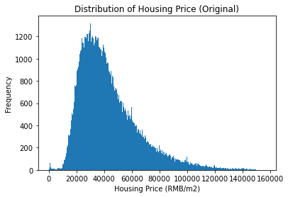

```python
ax = housing_raw.price.plot.hist(bins=1000,
                                 title='Distribution of Housing Price (Original)');
ax.set_xlabel("Housing Price (RMB/m2)");
```

## Preliminary study of the relationship

```python
housing_raw.corr(method='pearson')['price'].sort_values(ascending=False)
```

```
price                  1.000000
communityAverage       0.683768
totalPrice             0.622658
renovationCondition    0.294859
followers              0.257173
subway                 0.232571
DOM                    0.215473
elevator               0.050528
buildingStructure      0.042889
district               0.034186
fiveYearsProperty      0.014151
kitchen                0.013289
ladderRatio            0.001107
Cid                   -0.000387
buildingType          -0.048676
Lat                   -0.052004
Lng                   -0.153212
square                -0.164734
Name: price, dtype: float64
```

It appears that the "communityAverage" has the highest positive linear relationship, whereas the "square" has highest negative linear relationship"

## Pairplot

Pair plot to visualize the relationship between each feature

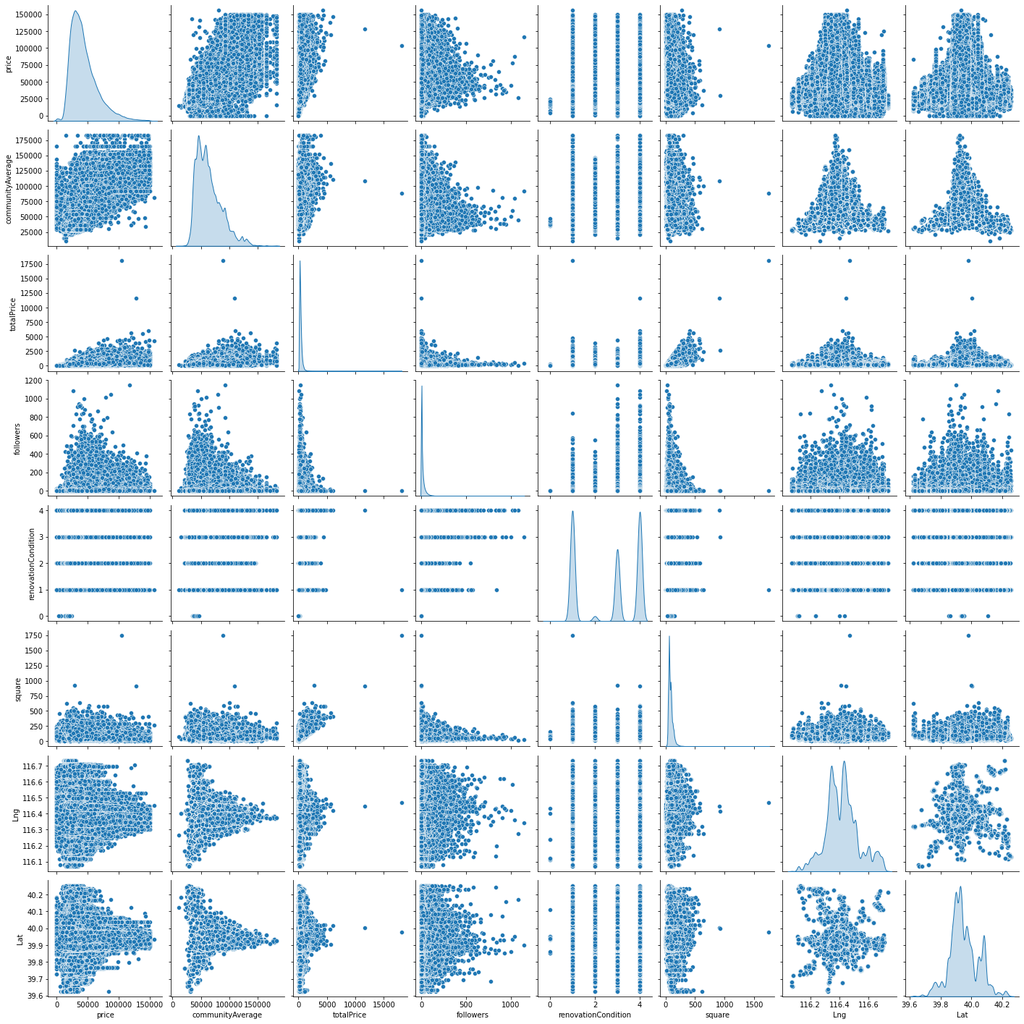

```python
import seaborn as sns;
sns.pairplot(housing_raw[['price', 'communityAverage', 'totalPrice', 'followers',
                      'renovationCondition', 'square', 'Lng', 'Lat']], diag_kind='kde');
```

Appears that only 'communityAverage' have somewhat a linear relationship with our target 'Price'

# 3.1 Data Cleaning

## Remove outliers in the data

```python
# create a copy of Raw
housing = housing_raw.copy()

# Remove non-real numbers
housing = housing[housing.livingRoom.apply(np.isreal)]

def remove_outlier(df, variable):
    """
    For removing outliers based on IQR method

    Parameters
    ----------
    df : pandas dataframe
    variable : str, column name of the dataframe
    """
    # Computing IQR
    Q1 = df[variable].quantile(0.25)
    Q3 = df[variable].quantile(0.75)
    IQR = Q3 - Q1

    # Filtering Values between Q1-1.5IQR and Q3+1.5IQR
    filtered = df.query(f'(@Q1 - 1.5 * @IQR) <= {variable} <= (@Q3 + 1.5 * @IQR)').reset_index(drop=True)
    return filtered

# Remove Outlier based on price
housing = remove_outlier(housing, 'price')

# Drop unneeded columns
housing.drop(['url', 'id', 'Cid'], axis=1, inplace=True)
```

## New distribution of housing price after removal of outliers

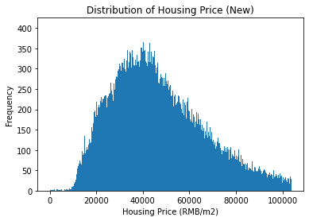

```python
ax = housing.price.plot.hist(bins=1000,
                        title='Distribution of Housing Price (New)')
ax.set_xlabel("Housing Price (RMB/m2)");
```

# 3.4 Data Visualization

## Functions for visualization

```python
def show_map(df, variable, scale=1., sep='k', tick_n=11, heatmap_label=None):
    """For plotting distribution on map"""
    import matplotlib.image as mpimg
    beijing_img = mpimg.imread('Images/beijingmap_baidu.png') #baidu

    ax = df.plot(kind='scatter', x="Lng", y='Lat', alpha=0.04,
                 s=df["followers"]/2, label="Followers",
                 c=variable, cmap=plt.get_cmap("jet"),
                 colorbar=False, figsize=(20, 10))
    plt.imshow(beijing_img, extent=[115.1946, 117.48, 39.495, 40.33], alpha=0.6,
               cmap=plt.get_cmap("jet")) # baidu

    plt.ylabel("Latitude", fontsize=12)
    plt.xlabel("Longitude", fontsize=12)

    prices = df[variable] * scale
    tick_values = np.linspace(prices.min(), prices.max(), tick_n)
    cbar = plt.colorbar(ticks=tick_values / prices.max(), fraction=0.046, pad=0.04)

    def separator(sep):
        if sep == 'k': #thousand separator
            sep_ = 'k'
            div = 1_000
        elif sep == 'M': #million separator
            sep_ ='M'
            div = 1_000_000
        elif sep == None:
            sep_ = ''
            div = 1

        cbar.ax.set_yticklabels([f"%d{sep_}"%round((v/div)) for v in tick_values], fontsize=12)

    separator(sep)
    cbar.set_label(heatmap_label, fontsize=12)

    plt.legend(fontsize=16)

    plt.xlim([115.9, 116.8])
    plt.ylim([39.5, 40.3])
    plt.show()

def save_fig(fig_id, tight_layout=True, fig_extension="png", resolution=300):
    """Save plotted figure"""
    path = os.path.join(IMAGES_PATH, fig_id + "." + fig_extension)
    print("Saving figure", fig_id)
    if tight_layout:
        plt.tight_layout()
    plt.savefig(path, format=fig_extension, dpi=resolution)
```

## Distribution of Housing Price

[figure not shown]

```python
# Display the distribution of housing price at Beijing Area
show_map(housing, "price", heatmap_label='House Price [RMB/m2]')
```

It appears that the center of the Beijing has the higher price, and the price decreaases as they are moving further away from the center

## Visualize for community average and tradeTime

```python
# groupby the tradeTime & community pivot variables
tradetime_pivot = housing.groupby('tradeTime')['price'].mean()
community_pivot = housing.groupby('communityAverage')['price'].mean()
```

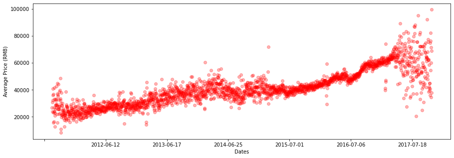

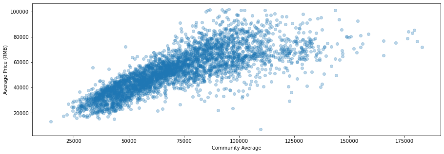

```python
import matplotlib.pyplot as plt
import matplotlib.dates as mdates

f1 = plt.figure(figsize=(15, 5))
f2 = plt.figure(figsize=(15, 5))
ax1 = f1.add_subplot(111)
ax1.scatter(tradetime_pivot.index, tradetime_pivot.values,color='red', alpha=0.3)
ax1.set(xlabel='Dates', ylabel='Average Price (RMB)')
ax1.xaxis.set_major_locator(mdates.MinuteLocator(interval=60*24*365)) # # tickmark frequency'
# ax1.xaxis.set_major_formatter(mdates.DateFormatter('%Y'))

ax2 = f2.add_subplot(111)
ax2.scatter(community_pivot.index, community_pivot.values, alpha=0.3)
ax2.set(xlabel='Community Average', ylabel='Average Price (RMB)')
plt.show()
```

Shows that the price increase over time, and generally have a linear relationship between average price & community average

# 3.5 Machine Learning

# 3.5.1 Feature Engineering

## Feature Selection

```python
house = housing.copy()

# Drop DOM & totalPrice
house.drop(columns=['totalPrice', 'communityAverage'], inplace=True)
```

- 'totalPrice' is dropped, as we can directly calculate target unit price based on the 'totalPrice' divided by 'square' the area of the house already, which gives an unfair prediction
- 'communityAverage' is dropped with similar reason, although no direct relationship, this variable already give a hint what the price range would be, so will make the price predictor less useful

## Feature Transformation

```python
# Convert Trading time to year only
house.tradeTime = pd.to_datetime(house.tradeTime).dt.strftime("%Y")

# convert desired data to numeric
house['tradeTime'] = pd.to_numeric(house['tradeTime'])
house['livingRoom'] = house['livingRoom'].apply(pd.to_numeric, errors='coerce')
house['drawingRoom'] = house['drawingRoom'].apply(pd.to_numeric, errors='coerce')
house['bathRoom'] = house['bathRoom'].apply(pd.to_numeric, errors='coerce')
house['constructionTime'] = house['constructionTime'].apply(pd.to_numeric, errors='coerce')

# Convert the floor to numeric
house.floor = house.floor.str.split(' ').str[1].astype('float')
```

```python
# Check null data
house.isna().mean().sort_values(ascending=False)
```

```
DOM                    0.382002
constructionTime       0.059138
buildingType           0.005971
district               0.000000
drawingRoom            0.000000
Lat                    0.000000
tradeTime              0.000000
followers              0.000000
price                  0.000000
square                 0.000000
livingRoom             0.000000
bathRoom               0.000000
kitchen                0.000000
subway                 0.000000
floor                  0.000000
renovationCondition    0.000000
buildingStructure      0.000000
ladderRatio            0.000000
elevator               0.000000
fiveYearsProperty      0.000000
Lng                    0.000000
dtype: float64
```

## Check correlation

```python
## Check correlation
corr = house.corr()['price'].sort_values(ascending=False)
corr
```

```
price                  1.000000
tradeTime              0.447050
subway                 0.289839
renovationCondition    0.252012
followers              0.201779
DOM                    0.149165
elevator               0.068200
floor                  0.050227
buildingStructure      0.044247
kitchen                0.016261
ladderRatio            0.002853
fiveYearsProperty     -0.006965
livingRoom            -0.044385
bathRoom              -0.045313
Lat                   -0.054322
buildingType          -0.064838
drawingRoom           -0.090902
square                -0.122343
constructionTime      -0.190963
district              -0.213320
Lng                   -0.300616
Name: price, dtype: float64
```

## 3.1 Check significance of the correlation

```python
from scipy.stats.stats import pearsonr

housing_corr = housing.dropna() # dropna for correlation significant test
for column in housing_corr:
    try:
        coefficient, pvalue = pearsonr(housing_corr[column], housing_corr.price)
        if pvalue <= 0.05:
            signif = 'Significant'
        else:
            signif = 'Not Significant'

        print(f"{column} : {pvalue} ({signif})")
    except TypeError:
        pass # pass for non-numeric
```

```
Lng : 0.0 (Significant)
Lat : 5.37959749575885e-77 (Significant)
DOM : 0.0 (Significant)
followers : 0.0 (Significant)
totalPrice : 0.0 (Significant)
price : 0.0 (Significant)
square : 0.0 (Significant)
livingRoom : 2.3146073388651423e-77 (Significant)
drawingRoom : 3.284291073595476e-153 (Significant)
kitchen : 1.502704591808757e-20 (Significant)
bathRoom : 1.9398351120344218e-86 (Significant)
buildingType : 1.5248644612175487e-82 (Significant)
renovationCondition : 0.0 (Significant)
buildingStructure : 1.1702122174052774e-46 (Significant)
ladderRatio : 0.3844034184575325 (Not Significant)
elevator : 1.9032496713893712e-78 (Significant)
fiveYearsProperty : 0.00047288418460049507 (Significant)
subway : 0.0 (Significant)
district : 2.253062848215524e-283 (Significant)
communityAverage : 0.0 (Significant)
```

```python
# Prepare the data for features and target for machine learning
X = house.drop('price', axis=1)
y = house['price'].copy()
```

- Drop the 'price' variable, as it is the target that we want to predict
- make a copy to the original dataframe, to avoid directly amend on it

## Imputation

```python
# Impute those null values with median
from sklearn.impute import SimpleImputer
imputer = SimpleImputer(strategy="median")

imputer.fit(X)
X_imp = imputer.transform(X)

X = pd.DataFrame(X_imp, columns=X.columns)
```

## Normalization

```python
# Normalize the columns value

from sklearn.preprocessing import MinMaxScaler
scaler = MinMaxScaler()

X = scaler.fit_transform(X)
```

## Test-train split

```python
# Perform test-train split, to split training set and validation set
from sklearn.model_selection import train_test_split

X_train, X_test, y_train, y_test = train_test_split(X, y, test_size=0.2, random_state=10)
```

# 5.3.2 Development & Testing of Machine Learning Models

## Functions for checking accuracy & error

```python
from sklearn.metrics import mean_absolute_error, mean_squared_error
from sklearn.model_selection import cross_val_score

def display_scores(model, X_train, y_train, X_test, y_test):
    def rmse(X, y):
        scores = cross_val_score(model, X, y,
                                 scoring="neg_mean_squared_error", cv=10)
        rmse_scores = np.sqrt(-scores)
        return rmse_scores
    rmse_train_scores = rmse(X_train, y_train)
    rmse_test_scores = rmse(X_test, y_test)

    # Model Scores
    train_score = model.score(X_train, y_train)
    test_score = model.score(X_test, y_test)

    print("Training Set")
    print("-"*50)
    print("Training set: ", train_score)
    print("Scores: ", rmse_train_scores)
    print("Mean: ", rmse_train_scores.mean())
    print("Standard deviation: ", rmse_train_scores.std())
    print("\n"*2)
    print("Testing Set")
    print("-"*50)
    print("Testing set: ", test_score)
    print("Scores: ", rmse_test_scores)
    print("Mean: ", rmse_test_scores.mean())
    print("Standard deviation: ", rmse_test_scores.std())

    y_train_predict = model.predict(X_train)
    y_test_predict = model.predict(X_test)

    # Return the predictions & Scores on testing set
    return y_test_predict, rmse_test_scores, test_score
```

## Linear Regression

```python
%%time
from sklearn.linear_model import LinearRegression

lin_model = LinearRegression()
lin_model.fit(X_train, y_train)
```

```
Wall time: 122 ms
```

```
LinearRegression()
```

```python
lin_y_test_predict, lin_test_rmse, lin_test_score = display_scores(lin_model, X_train,
                                                                   y_train, X_test, y_test)
```

```
Training Set
--------------------------------------------------
Training set:  0.3922021305128296
Scores:  [1.55398979e+04 1.54304302e+04 1.56293439e+04 2.91847728e+08
 1.55110086e+04 1.55769351e+04 1.56182486e+04 1.56349769e+04
 1.57163011e+04 1.55200834e+04]
Mean:  29198790.504441958
Standard deviation:  87549645.77145724



Testing Set
--------------------------------------------------
Testing set:  0.38963802993207375
Scores:  [15181.49349027 15602.00301256 15277.20618439 15728.88385498
 15652.04596508 15769.55168678 15630.58089759 15473.9067273
 15353.59897298 15589.38036114]
Mean:  15525.86511530744
Standard deviation:  187.11394909797588
```

## Ridge

```python
%%time
from sklearn.linear_model import Ridge

ridge_model = Ridge()
ridge_model.fit(X_train, y_train);
```

```
Wall time: 44.9 ms
```

```
Ridge()
```

```python
ridge_y_test_predict, ridge_test_rmse, ridge_test_score = display_scores(ridge_model, X_train,
                                                                      y_train, X_test, y_test)
```

```
Training Set
--------------------------------------------------
Training set:  0.39219690900606996
Scores:  [15539.66696422 15430.72504947 15629.49268487 15557.34685628
 15509.93875014 15576.25688942 15619.23764477 15635.57303581
 15714.73912073 15520.42815732]
Mean:  15573.340515302369
Standard deviation:  75.949290861016



Testing Set
--------------------------------------------------
Testing set:  0.38961320757772466
Scores:  [15196.57206072 15617.22555004 15281.3113787  15735.94875968
 15640.55392982 15765.82301535 15648.03248591 15482.96552874
 15374.2384525  15615.33919114]
Mean:  15535.801035259437
Standard deviation:  183.91027746204216
```

## Lasso

```python
%%time
from sklearn.linear_model import Lasso

lasso_model = Lasso()
lasso_model.fit(X_train, y_train)
```

```
Wall time: 195 ms
```

```
Lasso()
```

```python
lasso_y_test_predict, lasso_test_rmse, lasso_test_score  = display_scores(lasso_model, X_train,
                                                                          y_train, X_test, y_test)
```

```
Training Set
--------------------------------------------------
Training set:  0.3921741931480308
Scores:  [15539.47623686 15431.56720266 15630.30945467 15558.63895416
 15508.53968402 15576.08661665 15619.37756722 15636.6136606
 15714.20786669 15521.28811597]
Mean:  15573.61053595055
Standard deviation:  75.88806309911286



Testing Set
--------------------------------------------------
Testing set:  0.3895536396958257
Scores:  [15200.16141568 15614.85082674 15278.55141137 15735.72086776
 15638.74566624 15767.60413668 15649.64432374 15481.60001413
 15373.82171884 15612.36586039]
Mean:  15535.306624157016
Standard deviation:  183.6772928427326
```

Performing relatively bad on both linear and lasso, and ridge model

## Decision Tree

```python
%%time
from sklearn.tree import DecisionTreeRegressor

tree_model = DecisionTreeRegressor()
tree_model.fit(X_train, y_train)
```

```
Wall time: 2.47 s
```

```
DecisionTreeRegressor()
```

```python
tree_y_test_predict, tree_test_rmse, tree_test_score = display_scores(tree_model, X_train,
                                                                      y_train, X_test, y_test)
```

```
Training Set
--------------------------------------------------
Training set:  0.9998271083169152
Scores:  [8769.98728669 8962.62815655 8761.32811546 8755.95591985 8893.65814257
 8671.53252004 8814.43672265 8628.02441162 8833.39945692 8661.1146053 ]
Mean:  8775.206533764953
Standard deviation:  100.05066509181604



Testing Set
--------------------------------------------------
Testing set:  0.8122047027421231
Scores:  [10065.67909852  9886.69558761 10191.07439291 10152.09603857
 10084.88083025  9973.82021245 10177.40978044  9922.20893092
  9796.57853624  9912.47004651]
Mean:  10016.291345442143
Standard deviation:  129.8452097613027
```

## Random Forest

```python
%%time
# Random Forest (Full)

from sklearn.ensemble import RandomForestRegressor


if os.path.isfile('randomforest.sav'):
    forest_model = load_model('randomforest.sav')
else:
    forest_model = RandomForestRegressor()
    forest_model.fit(X_train, y_train)
```

```
Wall time: 2min 22s
```

```python
forest_y_test_predict, forest_test_rmse, forest_test_score = display_scores(forest_model, X_train, y_train,
                                                               X_test, y_test)
```

[output not shown]

```python
#  forest_test_rmse = [7092.28775047, 7244.6936723,  7423.91627079, 7504.32111199, 7507.67920291,
# 7121.99076411, 7337.94371255, 7189.33832306, 7206.38143608, 7275.36728212]

# forest_test_rmse = np.array(forest_test_rmse)
```

```python
# Save and load model
import pickle

def save_model(model, filename):
    """Save Machine Learning Model"""
    pickle.dump(model, open(filename, 'wb'))

def load_model(filename):
    """Load Machine Learning Model"""
    model = pickle.load(open(filename, 'rb'))
    return model

# # for saving the model
# save_model(forest_model, 'randomforest.sav')

# # For loading the model
# forest_model = load_model('randomforest.sav')
```

```python
%%time
## Support Vector Machine

from sklearn.svm import SVR

svm_model = SVR(kernel='rbf')
svm_model.fit(X_train, y_train)
```

```
Wall time: 19min 54s
```

```
SVR()
```

```python
svm_y_test_predict, svm_test_rmse, svm_test_score = display_scores(svm_model,X_train, y_train,
                                                               X_test, y_test)
```

[output not shown]

```python
%%time
# Gradient Boosting Regressor
from sklearn.ensemble import GradientBoostingRegressor

gb_model = GradientBoostingRegressor(random_state=0)
gb_model.fit(X_train, y_train)
```

```
Wall time: 38.1 s
```

```
GradientBoostingRegressor(random_state=0)
```

```python
gb_y_test_predict, gb_test_rmse, gb_test_score = display_scores(gb_model, X_train,
                                                                   y_train, X_test, y_test)
```

```
Training Set
--------------------------------------------------
Training set:  0.7843929755840663
Scores:  [9261.51748819 9251.02818692 9304.89613114 9307.66934506 9271.56742484
 9136.8333375  9277.915862   9253.80039438 9253.12391271 9236.35095486]
Mean:  9255.47030376075
Standard deviation:  45.205582588211605



Testing Set
--------------------------------------------------
Testing set:  0.7832309350609137
Scores:  [8850.62511927 9093.33142373 9233.28738005 9428.76663509 9298.09479491
 9261.72313824 9193.9799223  9203.50442446 9081.77529892 9299.35458335]
Mean:  9194.444272031236
Standard deviation:  149.63416201028306
```

## Deep Neural Network

```python
import tensorflow as tf

from tensorflow import keras
from tensorflow.keras import layers
from tensorflow.keras.layers.experimental import preprocessing
```

```python
# Perform Normalization for the features
normalizer = preprocessing.Normalization()
normalizer.adapt(X_train)
```

```python
def build_and_compile_model(norm):
    model = keras.Sequential([
      norm,
      layers.Dense(15, activation='relu'),
      layers.Dense(15, activation='relu'),
      layers.Dense(10, activation='relu'),
      layers.Dense(5, activation='relu'),
      layers.Dense(1)
    ])

    model.compile(loss='mse',
                  metrics=[tf.keras.metrics.RootMeanSquaredError()],
                  optimizer=tf.keras.optimizers.Adam(0.001))
    return model
```

```python
dnn_model = build_and_compile_model(normalizer)
dnn_model.summary()
```

```
Model: "sequential_5"
_________________________________________________________________
Layer (type)                 Output Shape              Param #
=================================================================
normalization (Normalization (None, 20)                41
_________________________________________________________________
dense_25 (Dense)             (None, 15)                315
_________________________________________________________________
dense_26 (Dense)             (None, 15)                240
_________________________________________________________________
dense_27 (Dense)             (None, 10)                160
_________________________________________________________________
dense_28 (Dense)             (None, 5)                 55
_________________________________________________________________
dense_29 (Dense)             (None, 1)                 6
=================================================================
Total params: 817
Trainable params: 776
Non-trainable params: 41
_________________________________________________________________
```

sqrt(input layer nodes * output layer nodes)

## Fitting deep neural network model

```python
%%time
# starts the machine learning
history = dnn_model.fit(
    X_train, y_train,
    validation_split=0.2,
    verbose=1, epochs=300)
```

```
Wall time: 26min 36s
```

```python
def plot_loss(history):
    """For ploting the losses over Epoch"""
    plt.figure(figsize=(20, 10))
    plt.plot(history.history['loss'], label='loss')
    plt.plot(history.history['val_loss'], label='val_loss')
    plt.xlabel('Epoch')
    plt.ylabel('Error [price]')
    plt.legend()
    plt.grid(True)
```

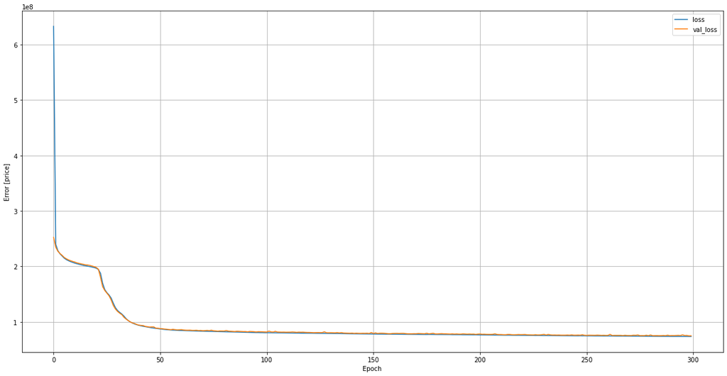

```python
plot_loss(history)
```

## Collect the results on the test set:

```python
test_results = {}
test_results['dnn_model'] = dnn_model.evaluate(X_test, y_test, verbose=0)
dnn_test_rmse = test_results['dnn_model'][1]
test_results
```

```
{'dnn_model': [74283744.0, 8618.8017578125]}
```

```python
## Prediction
dnn_y_test_predict = dnn_model.predict(X_test).flatten()
```

```python
# # Save dnn model
# dnn_model.save('dnn_model_2')

# Load model
# dnn_model = tf.keras.models.load_model('dnn_model')
```

[output not shown]

```python
import tensorflow_addons as tfa

def coefficient_R_dnn(y_true, y_predict):
    metric = tfa.metrics.r_square.RSquare()
    metric.update_state(y_true, y_predict)
    result = metric.result()
    rsquared = result.numpy()
    return rsquared

dnn_test_score = coefficient_R_dnn(y_test, dnn_y_test_predict)
```

```python
dnn_test_score
```

```
0.811966
```

# 4.0 Results & Discussion

## Overall Results

```python
forest_test_score = forest_model.score(X_test, y_test)
```

```python
# Results
# R squared values
result_data = {
'R Squared':{
'Linear Regression': lin_test_score,
'Ridge Regression': ridge_test_score,
'Lasso Regression': lasso_test_score,
'Decision Tree': tree_test_score,
'Random Forest': forest_test_score,
'Gradient Boosting': gb_test_score,
'Deep Neural Network': dnn_test_score
},
'RMSE':{
'Linear Regression': lin_test_rmse.mean(),
'Ridge Regression': ridge_test_rmse.mean(),
'Lasso Regression': lasso_test_rmse.mean(),
'Decision Tree': tree_test_rmse.mean(),
'Random Forest': forest_test_rmse.mean(),
'Gradient Boosting': gb_test_rmse.mean(),
'Deep Neural Network': dnn_test_rmse
}
}
```

```python
results = pd.DataFrame(data).sort_values(by='RMSE')
```

```python
results
```

|  | R Squared | RMSE |
| --- | --- | --- |
| Random Forest | 0.899249 | 7290.390000 |
| Deep Neural Network | 0.811966 | 8618.801758 |
| Gradient Boosting | 0.783231 | 9194.444272 |
| Decision Tree | 0.812205 | 10016.291345 |
| Linear Regression | 0.389638 | 15525.865115 |
| Lasso Regression | 0.389554 | 15535.306624 |
| Ridge Regression | 0.389613 | 15535.801035 |

## Visualize the predicted results for accuracy

### Functions for visualize the prediction Results

```python
# Function for plot
def match_plot(y_test=y_test, y_test_predict=None, name=None):
    """Plot Prediction & Actual Overlapping plot"""
    num = 100
    z1 = y_test[:num].to_list()
    z2 = y_test_predict[:num]

    # for the title for model name
    if name == None:
        name = ""
    else:
        name = "[" + name + "]"

    df = pd.DataFrame(list(zip(z1, z2)), columns=['Actual', 'Predicted'])
    ax = df.plot(figsize=(10, 5), title=f'{name} Difference Between Actual & Predicted Price')
    ax.set_ylabel("Price (RMB/m2)")
    ax.set_xlabel("Count (Data)")
    return df;

# Function for plot
def plot_actual_predicted(y_test=y_test, y_test_predict=None, name=None):
    """
    Ploting Predicted vs. Actual Price graph
    Parameters
    --------------
    y_test : array,
    y_predict : predicted y
    title : title of the chart

    """
    if name == None:
        name = ""
    else:
        name = "[" + name + "]"

    fig, ax = plt.subplots(figsize=(10, 5))
    ax.scatter(x=y_test, y=y_test_predict, alpha=0.2)
    ax.set(title=f"{name} Actual Price vs. Predicted Price",
           xlabel='Actual Price (RMB)', ylabel='Predicted Price (RMB)');
    lims = [0, y_test.max()]
    _ = plt.plot(lims, lims, '--k')
    plt.show()

# Combine 2 plots
def check_plot(y_test, y_test_predict, name):
    """Display 2 plots together"""
    df = match_plot(y_test, y_test_predict, name)
    plot_actual_predicted(y_test, y_test_predict, name)

    return df
```

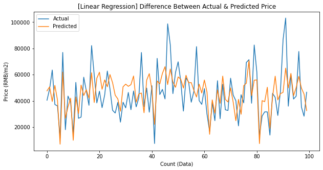

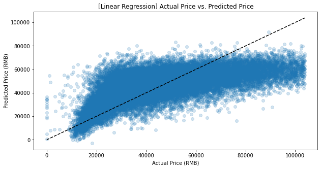

```python
# Linear Regression
lin_df = check_plot(y_test=y_test, y_test_predict=lin_y_test_predict, name='Linear Regression')
```

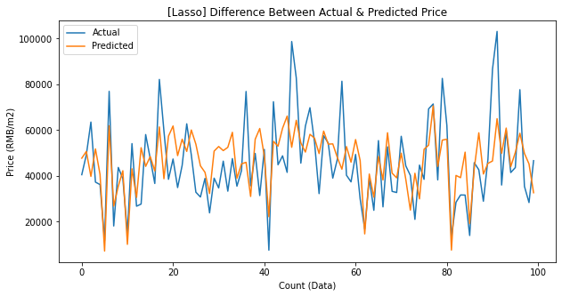

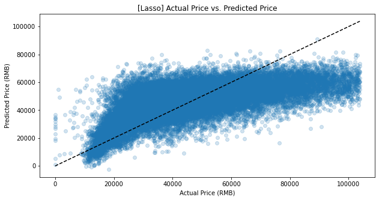

```python
# Lasso
lasso_df = check_plot(y_test, y_test_predict=lasso_y_test_predict, name='Lasso')
```

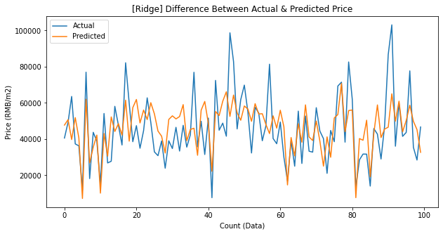

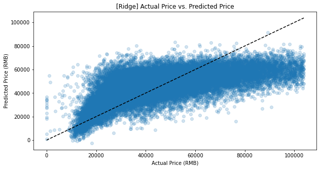

```python
# ridge
ridge_df = check_plot(y_test, y_test_predict=ridge_y_test_predict, name='Ridge')
```

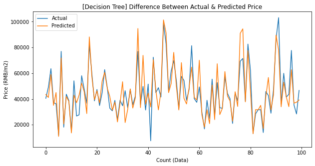

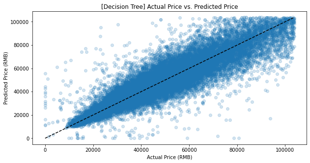

```python
# Decision Tree
tree_df = check_plot(y_test, y_test_predict=tree_y_test_predict, name='Decision Tree')
```

```python
# Random Forest
forest_df = check_plot(y_test, y_test_predict=forest_y_test_predict, name='Random Forest')
```

[output not shown]

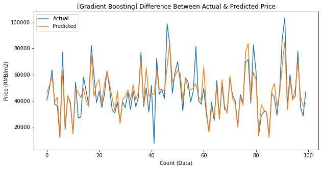

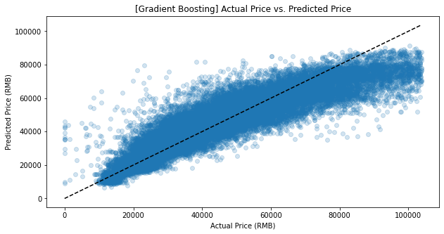

```python
# Gradient Boosting
gb_df = check_plot(y_test, y_test_predict=gb_y_test_predict, name='Gradient Boosting')
```

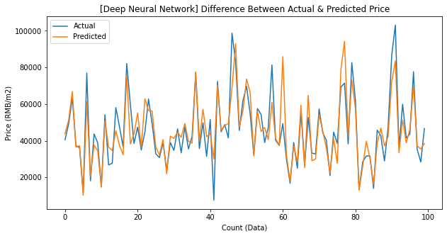

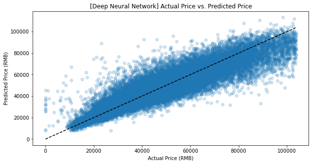

```python
# Deep Neural Network
dnn_df = check_plot(y_test, y_test_predict=dnn_y_test_predict, name='Deep Neural Network')
```

## Visualzie for Deep Neural Networks